# R code for Figure 3 - figure supplement 3 - expression of species-enriched genes in published single nuclei data

#### Distribution of gene expression for each class of genes

For each cell type, plot distribution of gene expression for housekeeping, human-enriched, and mouse-enriched genes. From violin plots, looks like even marker genes have 0 expression in most samples. For summary stats, use either mean or % of cells that express gene over threshold of 1. Because our astrocyte population contains both Bergmann glia (cerebellar astrocytes) and conventional astrocytes, look at expression of these genes in both single nulcei populations. Use Kolmogorov-Smirnov test to determine whether differences in distribution are significant.

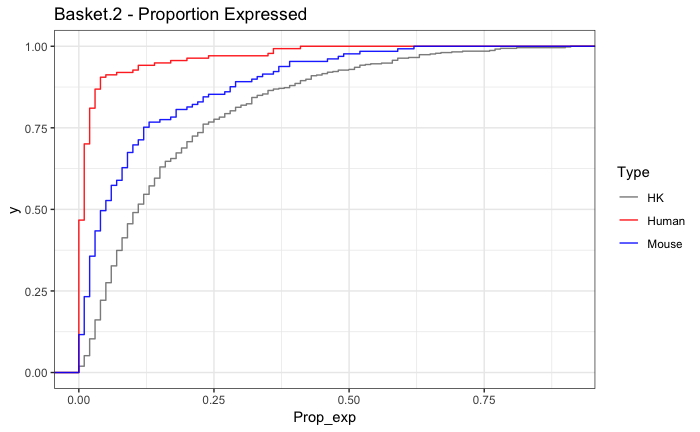

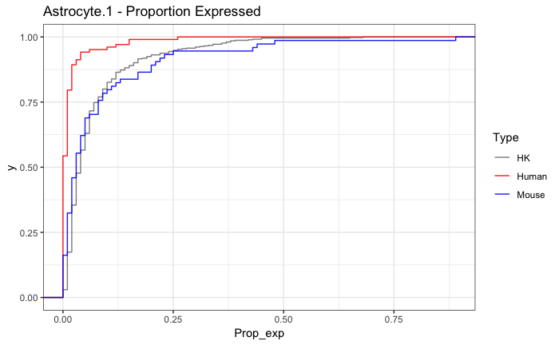

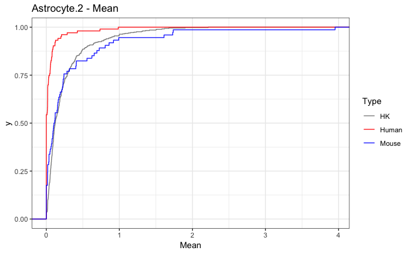

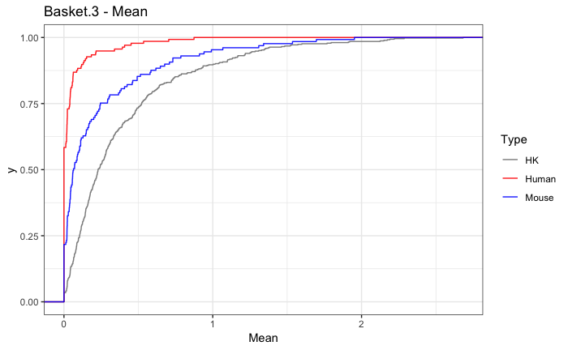

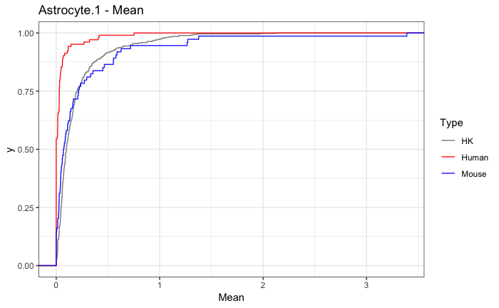

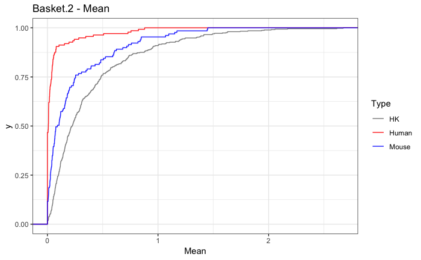

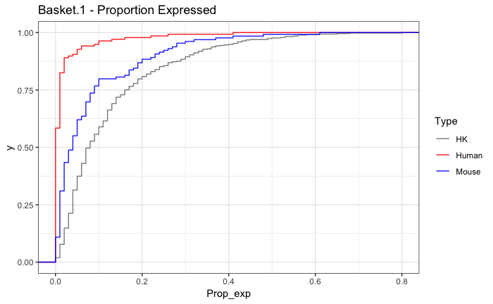

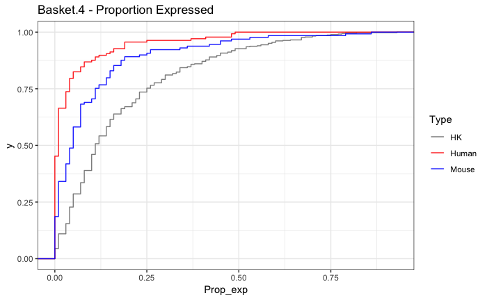

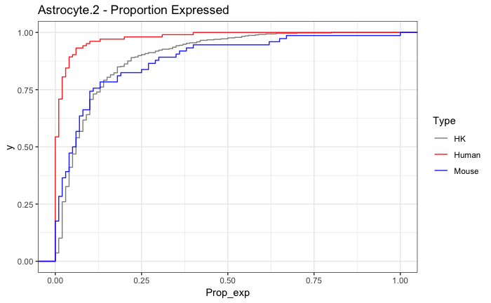

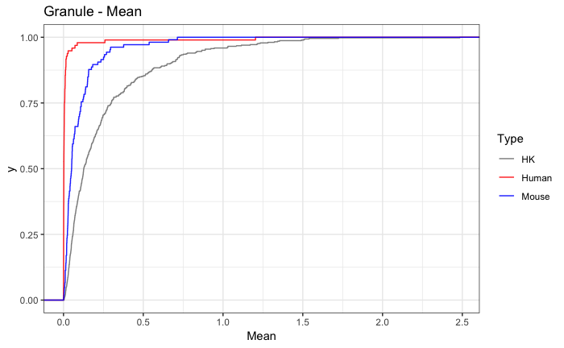

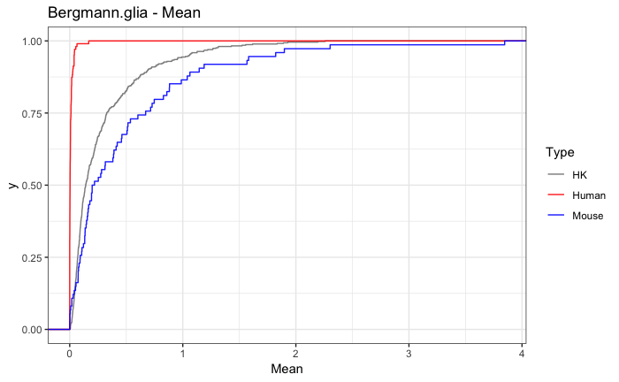

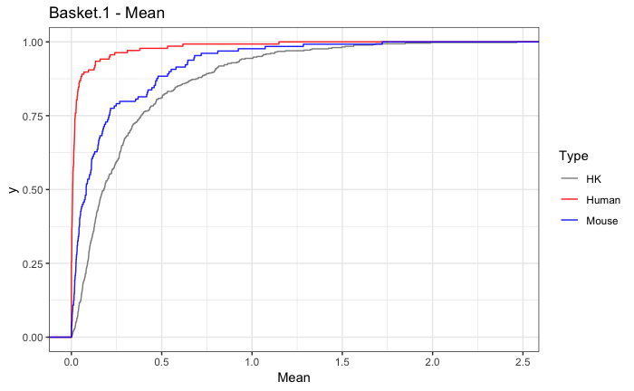

[10 more figures not shown]

```r
comparisons <- tibble(
  Cell_type_SE = c("Granule", rep("Basket", 4), rep("Astrocyte", 3),
                   rep("Oligo", 2), "OPC"),
  Cell_type_SN = c("Granule", "Basket.1", "Basket.2", "Basket.3", "Basket.4",
                   "Astrocyte.1", "Astrocyte.2", "Bergmann.glia", "Oligo.1",
                   "Oligo.2", "OPC")
)
plotDist <- function(x, y) {
  # subset for housekeeping genes or species-enriched genes
  genes_sub <- genes %>%
    filter(Cell_type %in% c(y, "HK")) %>%
    mutate(Gene = convertIDs(Gene, from = "human", to = "mouse"))

  # get normalized counts for gene subset - reshape
  norm_counts <- cb_sn_ms@data[rownames(cb_sn_ms@data) %in% genes_sub$Gene, ] %>%
    as.matrix() %>%
    t() %>%
    as.data.frame() %>%
    rownames_to_column("Name") %>%
    left_join(meta_ms, by = "Name") %>%
    melt() %>%
    rename(Gene = variable) %>%
    filter(Cell_type == x) %>%
    left_join(genes_sub %>% select(-Cell_type), by = "Gene")

  # mean
  gene_sum <- norm_counts %>%
    group_by(Gene, Type) %>%
    summarise(Mean = mean(value))

  # plot cdf for mean
  plotCDF(gene_sum, "Mean", "Type", c("grey50", "red", "blue"),
          paste(x, " - Mean", sep = ""),
          paste("../figures/figure_3_s3_mouse_cdf_mean_", tolower(x), ".pdf", sep = ""))


  # for each gene, % of nuclei with expression above 1
  gene_sum_exp <- norm_counts %>%
    group_by(Gene, Type, value > 1) %>%
    count() %>%
    spread("value > 1", n) %>%
    rename("Not_exp" = "FALSE", "Exp" = "TRUE") %>%
    replace_na(list(Not_exp = 0, Exp = 0)) %>%
    mutate(Total = Not_exp + Exp) %>%
    mutate(Prop_exp = round(Exp / Total, 2))

  # plot proportion expressed
  plotCDF(gene_sum_exp, "Prop_exp", "Type", c("grey50", "red", "blue"),
          paste(x, " - Proportion Expressed", sep = ""),
          paste("../figures/figure_3_s3_mouse_cdf_prop_exp_", tolower(x), ".pdf", sep = ""))


  # Kolmogorov-Smirnov Tests
  ks_pvals <- c(
        ks.test(gene_sum %>% filter(Type == "Human") %>% pull(Mean),
                gene_sum %>% filter(Type == "Mouse") %>% pull(Mean))$p.value,
        ks.test(gene_sum_exp %>% filter(Type == "Human") %>% pull(Prop_exp),
                gene_sum_exp %>% filter(Type == "Mouse") %>% pull(Prop_exp))$p.value,
        ks.test(gene_sum %>% filter(Type == "Human") %>% pull(Mean),
                gene_sum %>% filter(Type == "HK") %>% pull(Mean))$p.value,
        ks.test(gene_sum_exp %>% filter(Type == "Human") %>% pull(Prop_exp),
                gene_sum_exp %>% filter(Type == "HK") %>% pull(Prop_exp))$p.value
        )

  return( formatC(ks_pvals, format = "e", digits = 2) )
}
ks_all_stats <- mapply(plotDist, comparisons$Cell_type_SN, comparisons$Cell_type_SE)
```

```r
rownames(ks_all_stats) <- c("Human_Mouse_mean", "Human_Mouse_prop_exp", "Human_HK_mean", "Human_HK_prop_exp")
ks_all_stats %>%
  as.data.frame() %>%
  rownames_to_column("Comparison")
```

| Comparison | Granule | Basket.1 | Basket.2 | Basket.3 | Basket.4 | Astrocyte.1 | Astrocyte.2 | Bergmann.glia | Oligo.1 | Oligo.2 | OPC |
| --- | --- | --- | --- | --- | --- | --- | --- | --- | --- | --- | --- |
| Human_Mouse_mean | 0.00e+00 | 0.00e+00 | 5.31e-14 | 3.17e-10 | 4.99e-07 | 2.60e-09 | 1.69e-08 | 0.00e+00 | 2.27e-12 | 1.32e-07 | 1.39e-01 |
| Human_Mouse_prop_exp | 0.00e+00 | 9.99e-16 | 4.49e-13 | 7.34e-10 | 1.88e-06 | 9.45e-09 | 4.30e-08 | 0.00e+00 | 1.82e-11 | 1.32e-07 | 2.00e-01 |
| Human_HK_mean | 0.00e+00 | 0.00e+00 | 0.00e+00 | 0.00e+00 | 0.00e+00 | 0.00e+00 | 0.00e+00 | 0.00e+00 | 0.00e+00 | 1.11e-16 | 4.52e-11 |
| Human_HK_prop_exp | 0.00e+00 | 0.00e+00 | 0.00e+00 | 0.00e+00 | 0.00e+00 | 0.00e+00 | 0.00e+00 | 0.00e+00 | 0.00e+00 | 0.00e+00 | 9.20e-07 |